# 13 Supervised learning with decision trees

REWATCH

Decision trees are powerful tools in the realm of machine learning and statistical analysis. They provide a graphical representation of decision-making processes and can be used for both classification and regression tasks. With their simple visual representation, they are interpretable, making them an attractive choice for many data scientists.

# Prepare the workspace

```r
options(
  digits = 2,
  scipen = 999,
  warn = -1
)
rm(
  list = ls()
)
library(magrittr)
```

# Load data

```r
M_mushrooms <- readr::read_csv(
  file = "/Users/thienpham/Data Mining/data/prepared_mushrooms.csv",
  col_types = "cnnnnnnnnnnnnnnnnnnnnnn"
) %>%
  dplyr::mutate(
    train_test = ifelse(runif(dplyr::n()) > 0.5,"Train","Test")
  ) %>%
  as.data.frame()
```

## Decision Trees: Basic Concepts

### What is a Decision Tree?

A decision tree is a flowchart-like tree structure in which: - Each internal node represents a “test” on an attribute (e.g., whether a coin flip comes up heads or tails). - Each branch represents the outcome of the test. - Each leaf node represents a class label (decision taken after computing all attributes).

The paths from the root to the leaf represent classification rules.

```r
M_Train <- M_mushrooms %>%
  dplyr::filter(train_test == "Train") %>%
  dplyr::select(-class,-train_test) %>%
  as.data.frame()
rpart_1 <- rpart::rpart(
  formula = target ~.,
  data = M_Train,
  method = "class",        # class for classification, other  method for regression,...
  control = rpart::rpart.control(
    cp = 0.001,           # complexity parameter used to control how many splits we have
    maxdepth = 3          # prevent things from getting too complicated
  )
)
rpart.plot::rpart.rules(
  x = rpart_1,
  style = "tallw"
)
```

```
## target is 0.00 when
##                odor is 0
##
## target is 0.47 when
##                odor is 1
##                spore_print_color is 0
##                population is 0
##
## target is 0.98 when
##                odor is 1
##                spore_print_color is 0
##                population is 1
##
## target is 1.00 when
##                odor is 1
##                spore_print_color is 1
```

```r
rpart.plot::rpart.plot(
  x = rpart_1,
  extra = 104 # 104 shows all the outputs we see below
)
```

[output not shown]

### Advantages

- Simple to understand and interpret.
- Requires little data preparation. (ANY TRANSFORMATION THAT DOESNT AFFECT ORDER OF DATA WILL NOT IMPROVE MODEL)
- Can handle both numerical and categorical data.

### Disadvantages

- Trees can be very non-robust.
- Decision-tree learners can create overly complex trees that do not generalize well from the training data.

## Building a Decision Tree

There are several algorithms to build a decision tree, but the most common ones include the ID3, C4.5, and CART.

### Criteria for Splitting

The decision of which attribute to split at each node is based on a measure. Some common measures are:

1. **Gini Impurity**: Used by the CART (Classification and Regression Trees) algorithm for classification trees.

$$\text{Gini}(t) = 1 - \sum_{i=1}^{c} p_i^2$$

2. **Information Gain**: This is used by the ID3 algorithm.

$$\text{Information Gain}(S, A) = \text{Entropy}(S) - \sum_{v \in
Values(A)} \frac{|S_v|}{|S|} \text{Entropy}(S_v)$$

Where:
$$\text{Entropy}(S) = -p_+ \log_2 p_+ - p_- \log_2 p_-$$

Here, $p_+$ and $p_-$ are the proportion of positive and negative examples in $S$, respectively.

3. **Variance Reduction**: Used for regression trees.

$$\text{Variance Reduction} = \text{variance before split} -
\text{weighted variance of each node after split}$$

## Data Preparation for Decision Trees

When building decision trees, as with most machine learning models, the state and quality of the data can have a profound effect on the model’s performance. Proper data preparation can alleviate many potential issues.

### Handling Categorical Columns

1. **Binary Categories**: If a categorical variable has only two categories (binary), it doesn’t need any transformation. However, it’s essential to ensure that the categories are represented in a format that the algorithm can understand, usually as 0 and 1.
2. **Multi-class Categories**: For categories with more than two levels, there are various encoding techniques:
   - **Dummy Variables**: This involves creating a binary column for each category and indicating the presence of the category with 1 or 0.
   - **Ordinal Encoding**: If there’s an inherent order in the categories (like “low”, “medium”, “high”), they can be converted to a single column of ordered numbers (like 1, 2, 3). However, decision trees inherently can handle ordinal predictors, and this encoding might not be necessary.
3. **Missing Values in Categorical Columns**: For decision trees, one common method is to treat missing values as another category. Another method involves using techniques like mode-imputation, where missing values are replaced with the most frequent category.

For numeric and ordinal predictors, tree models work to find the best single split in the data. If $k$ is the number of distinct values,

$$k-1$$
is the number of possible splits the model needs to consider. Rounding off values can improve computation time.

For categorical predictors, tree models work to bin levels into the best partition possible. If $k$ is the number of distinct levels,

$$2^k - 2$$
is the number of possible partitions. The empty-full and full-empty split are not considered. Binning can improve computation time and model accuracy.

Dummy variables can create excessive and useless predictors. It is best to bin the levels before one-hot encoding.

### Monotonic Transformations of Ordinal and Numeric Columns

A significant advantage of decision trees is their non-parametric nature. This means that the tree doesn’t assume any particular distribution for the features. As a result, monotonic transformations (i.e., transformations that don’t change the order of the values), such as taking the log, square root, or even more involved functions like Box-Cox transformations, will not change the performance of the tree.

Let’s delve deeper:

1. **Invariant to Monotonic Transformations**: The tree splits are based on ordering the values and checking for the best split point. Since a monotonic transformation preserves order, the relative order of all data points remains the same, and therefore, the tree’s structure and decisions remain unchanged.
2. **Scaling and Centering**: Similarly, decision trees are not affected by the scaling or centering of features. Whether a feature is in the range of 0-1 or 0-1000 doesn’t change the tree’s decisions.
3. **Practical Implications**: This property means that, for decision trees, we don’t have to worry about standardizing features or ensuring they’re on the same scale, as we might with models like linear regression or support vector machines. However, for tree visualization or for certain implementations, it might still be beneficial to keep features in a comprehensible scale or range.

## Preventing Overfitting in Tree Models

Overfitting is a common concern with decision trees, where a model might perform exceptionally well on training data but poorly on new, unseen data. This happens because the tree becomes too complex and starts capturing noise or fluctuations in the training data as patterns. To prevent overfitting, various methods and parameters can be tweaked:

### 1. **Tree Pruning**

**Tree pruning** involves trimming down a fully grown tree. The idea is to control the size and complexity of the tree by removing sections of it that provide little power in predicting the target variable.

- **Cost Complexity Pruning (CCP)**: This is a popular method where a complexity parameter is used to define a trade-off between the tree’s depth and its fit to the training set. As the complexity parameter increases, more nodes get pruned from the tree.

```r
# this model is overfit
rpart_cp <- rpart::rpart(
  formula = target ~.,
  data = M_Train,
  method = "class",
  control = rpart::rpart.control(
    cp = 0.001
  )
)
rpart.plot::rpart.rules(
  x = rpart_cp,
  style = "tallw"
)
```

```
## target is 0.00 when
##                odor is 0
##
## target is 0.14 when
##                odor is 1
##                spore_print_color is 0
##                population is 0
##                gill_spacing is 1
##                cap_color is 0
##
## target is 0.24 when
##                odor is 1
##                spore_print_color is 0
##                population is 0
##                gill_spacing is 1
##                cap_color is 1
##                bruises is 1
##
## target is 0.98 when
##                odor is 1
##                spore_print_color is 0
##                population is 1
##
## target is 1.00 when
##                odor is 1
##                spore_print_color is 0
##                population is 0
##                gill_spacing is 1
##                cap_color is 1
##                bruises is 0
##
## target is 1.00 when
##                odor is 1
##                spore_print_color is 0
##                population is 0
##                gill_spacing is 0
##
## target is 1.00 when
##                odor is 1
##                spore_print_color is 1
```

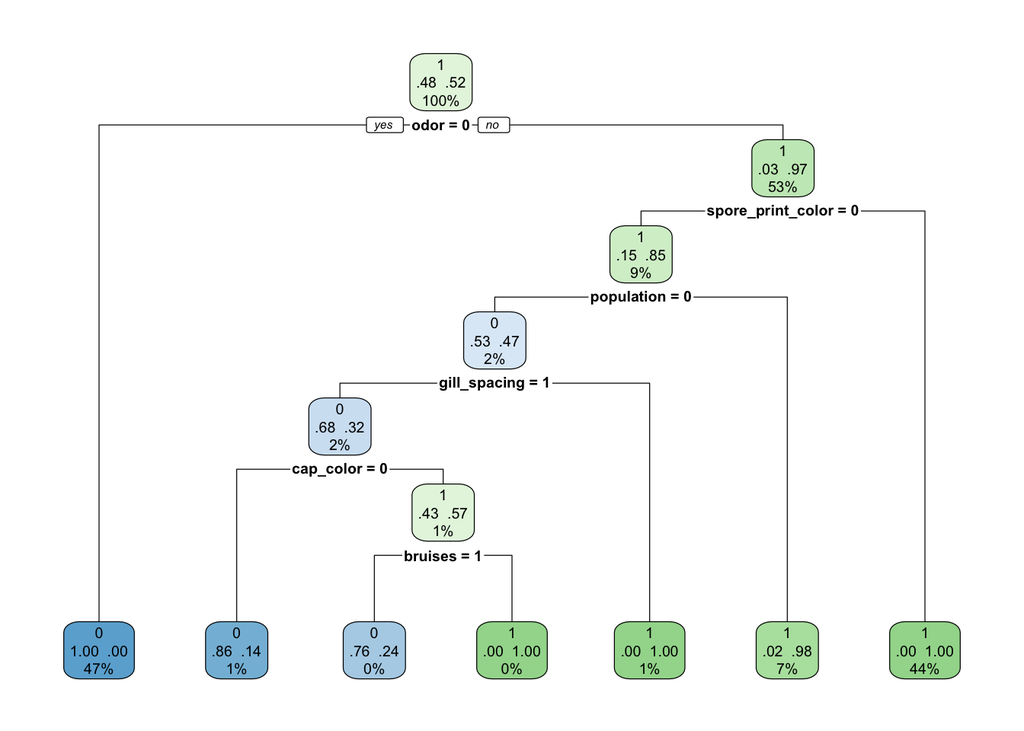

```r
rpart.plot::rpart.plot(
  x = rpart_cp,
  extra = 104
)
```

### 2. **Minimum Split**

This parameter sets the minimum number of data points a node should have before it’s split. By setting this value to be greater than 1:

- The tree becomes less flexible.
- The potential for overfitting decreases.
- However, if set too high, the tree might become too generalized.

```r
rpart_minsplit <- rpart::rpart(
  formula = target ~.,
  data = M_Train,
  method = "class",
  control = rpart::rpart.control(
    cp = 0, # 0 means dont prune at all
    minsplit = 100 # makes sure there is at least 100 obs in each node before splitting
  )
)
rpart.plot::rpart.rules(
  x = rpart_minsplit,
  style = "tallw"
)
```

```
## target is 0.00 when
##                odor is 0
##
## target is 0.47 when
##                odor is 1
##                spore_print_color is 0
##                population is 0
##
## target is 0.98 when
##                odor is 1
##                spore_print_color is 0
##                population is 1
##
## target is 1.00 when
##                odor is 1
##                spore_print_color is 1
```

```r
rpart.plot::rpart.plot(
  x = rpart_minsplit,
  extra = 104
)
```

[output not shown]

### 3. **Maximum Depth**

By setting a maximum depth for the tree:

- We limit how many splits a tree can have.
- This ensures that the tree doesn’t grow very deep and become overly complex.
- The right depth often requires cross-validation to determine.

```r
rpart_maxdepth <- rpart::rpart(
  formula = target ~.,
  data = M_Train,
  method = "class",
  control = rpart::rpart.control(
    cp = 0,
    maxdepth = 30 # depending on the package, this means 30 splits or nodes, here it means 30 split
  )
)
rpart.plot::rpart.rules(
  x = rpart_maxdepth,
  style = "tallw"
)
```

```
## target is 0.00 when
##                odor is 0
##
## target is 0.14 when
##                odor is 1
##                spore_print_color is 0
##                population is 0
##                gill_spacing is 1
##                cap_color is 0
##
## target is 0.24 when
##                odor is 1
##                spore_print_color is 0
##                population is 0
##                gill_spacing is 1
##                cap_color is 1
##                bruises is 1
##
## target is 0.98 when
##                odor is 1
##                spore_print_color is 0
##                population is 1
##
## target is 1.00 when
##                odor is 1
##                spore_print_color is 0
##                population is 0
##                gill_spacing is 1
##                cap_color is 1
##                bruises is 0
##
## target is 1.00 when
##                odor is 1
##                spore_print_color is 0
##                population is 0
##                gill_spacing is 0
##
## target is 1.00 when
##                odor is 1
##                spore_print_color is 1
```

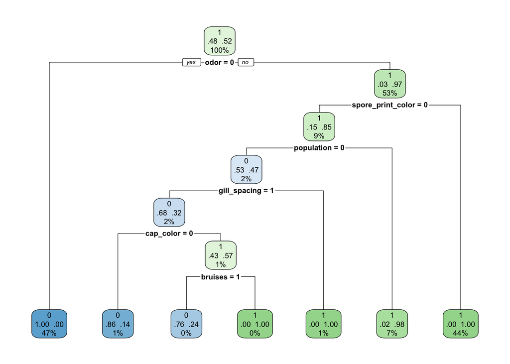

```r
rpart.plot::rpart.plot(
  x = rpart_maxdepth,
  extra = 104
)
```

### 4. **Minimum Leaf Size**

This parameter dictates the minimum number of data points permissible in a leaf (terminal node).

- By setting a minimum leaf size, we ensure that the tree doesn’t create very small leaves for outliers or very specific data points.
- Like the maximum depth, this parameter can prevent the tree from becoming overly detailed.

Point here is to go nuts, no pruning, minimum of 1 to see

```r
rpart_minbucket <- rpart::rpart(
  formula = target ~.,
  data = M_Train,
  method = "class",
  control = rpart::rpart.control(
    cp = 0,
    minbucket = 1
  )
)
rpart.plot::rpart.rules(
  x = rpart_minbucket,
  style = "tallw"
)
```

```
## target is 0.00 when
##                odor is 0
##
## target is 0.00 when
##                odor is 1
##                spore_print_color is 0
##                population is 0
##                gill_spacing is 1
##                cap_color is 1
##                bruises is 1
##                gill_color is 0
##
## target is 0.00 when
##                odor is 1
##                spore_print_color is 0
##                population is 1
##                veil_color is 0
##
## target is 0.00 when
##                odor is 1
##                spore_print_color is 0
##                population is 1
##                gill_spacing is 0
##                veil_color is 1
##                stalk_root is 1
##
## target is 0.14 when
##                odor is 1
##                spore_print_color is 0
##                population is 0
##                gill_spacing is 1
##                cap_color is 0
##
## target is 0.25 when
##                odor is 1
##                spore_print_color is 0
##                population is 0
##                gill_spacing is 1
##                cap_color is 1
##                bruises is 1
```

[output cut: 30 more lines]

```
##                population is 1
##                gill_spacing is 1
##                veil_color is 1
##                stalk_root is 1
##
## target is 1.00 when
##                odor is 1
##                spore_print_color is 0
##                population is 1
##                veil_color is 1
##                stalk_root is 0
##
## target is 1.00 when
##                odor is 1
##                spore_print_color is 1
```

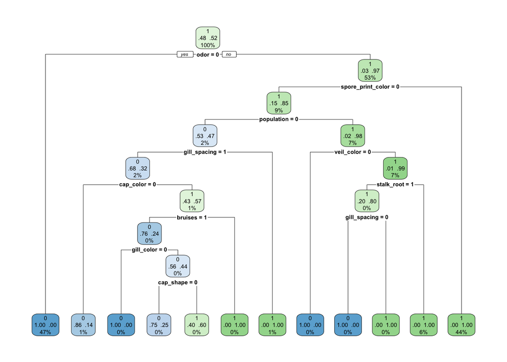

```r
rpart.plot::rpart.plot(
  x = rpart_minbucket,
  extra = 104
)
```

### 5. **Maximum Leaf Nodes**

Another way to control the size and complexity of the tree is by setting a maximum on the number of terminal nodes or leaves.

- This provides a rough control on the size of the tree.
- It can be particularly useful when you want a simple, interpretable tree.

### 6. **Minimum Impurity Decrease**

This parameter ensures that a node will only split if the split leads to a decrease in impurity greater than or equal to the set value.

- This avoids splits that don’t provide much informational gain.
- Helps in creating a more generalized tree.

## Shallow Trees for Interpretation and Inference

Decision trees, with their inherent visual representation of decision-making processes, offer a unique advantage in the realm of machine learning models: interpretability. Shallow trees, often referred to as “stumps” or small trees with limited depth, take this advantage a step further, prioritizing simplicity and clarity over maximal predictive accuracy. Here’s why and how shallow trees are used for interpretation and inference:

```r
rpart.plot::rpart.plot(
  x = rpart_minsplit,
  extra = 104
)
```

[output not shown]

### 1. **Simplicity is Key**

- **Fewer Splits**: Shallow trees have fewer splits, which means fewer decisions to follow and understand.
- **Fewer Variables**: With limited depth, shallow trees typically consider fewer variables, which can make it easier to focus on the main drivers or factors.

### 2. **Visual Interpretation**

- **Clear Visualization**: The tree structure can be easily visualized, allowing even non-experts to understand the decision-making process.
- **Decision Paths**: With fewer branches, it’s easier to trace through the tree and understand the specific path that leads to a particular decision or prediction.

### 3. **Inference about Important Features**

- **Highlight Key Features**: Shallow trees often split on the most important or informative features first. This can provide insights into which variables are most influential for the task at hand.
- **Feature Interactions**: Even in a shallow tree, if a variable appears more than once along a decision path, it can suggest interactions or nonlinear relationships with the target variable.

### 4. **Avoid Overfitting**

- **Generalization**: By their very nature, shallow trees are less prone to overfitting compared to deep trees. They tend to capture the more general patterns in the data rather than the nuanced specifics that might not generalize well.

### 5. **Speed and Efficiency**

- **Quick to Build**: With fewer nodes and decisions, shallow trees are computationally faster to construct.
- **Real-time Decisions**: Their simplicity allows them to make predictions quickly, which can be valuable in real-time decision-making systems.

### 6. **Ideal for Educational and Communication Purposes**

- **Teaching and Onboarding**: Shallow trees are excellent tools for introducing concepts of decision-making algorithms to students or stakeholders unfamiliar with machine learning.
- **Presentations**: For presentations to business or non-technical stakeholders, a shallow tree can illustrate how decisions are made without overwhelming the audience with complexity.

## Using Random Forests or Ensemble Methods

One of the best ways to prevent overfitting in decision trees is to use them as building blocks in ensemble methods.

- **Random Forests**, for example, build multiple decision trees and aggregate their results. The randomization introduced in feature selection and bootstrapped data sampling for each tree ensures that individual tree biases are minimized in the final model.
- **Gradient Boosting Machines (GBM)** and **XGBoost** also use trees but in a boosting framework. They build trees in sequence, where each tree tries to correct the errors of the previous ones.

## Detecting Interactions Using Decision Trees

Decision trees are uniquely suited to detect interactions among predictor variables without requiring any explicit specification about the nature of these interactions. This capability emerges from the hierarchical structure of the trees, where decisions made at one level can depend on decisions made at previous levels. Let’s dive into how decision trees can be employed to unearth interactions:

### 1. **What is an Interaction?**

An interaction between two or more predictor variables in a model exists when the effect of one predictor variable on the dependent variable changes depending on the level/value of another predictor variable. In a linear regression context, we would often model such interactions using interaction terms (e.g., $X_1 \times X_2$).

### 2. **Hierarchical Nature of Trees**

- The hierarchical structure of a decision tree naturally captures interactions. For instance, if a tree first splits on variable $X_1$ and then, in one of its branches, splits on $X_2$, it indicates that the decision based on $X_2$ is contingent upon the value of $X_1$. This is a form of interaction between $X_1$ and $X_2$.

### 3. **Unpacking the Interaction**

- **Directionality**: By following a decision path in the tree, we can infer not only the presence of an interaction but also its directionality. For instance, if $X_1 > a$ leads to a split on $X_2 > b$, but $X_1 \leq a$ does not consider $X_2$ at all, it suggests a specific interactive effect of $X_1$ and $X_2$ on the outcome.
- **Magnitude and Significance**: While the tree structure can highlight interactions, assessing the magnitude and significance of these interactions might require additional methods or looking at metrics like the Gini impurity or information gain at each split.

### 4. **Multilevel Interactions**

- Decision trees can also capture multilevel interactions (i.e., interactions among more than two predictors). If, after splitting on $X_1$ and $X_2$, the tree then splits on $X_3$ within a specific branch, it implies a three-way interaction among the variables.

### 5. **Visualization and Interpretation**

- **Tree Diagrams**: The visual representation of a decision tree can be invaluable for understanding interactions. The branching paths can be traced to see how decisions are contingent upon previous splits.
- **Partial Dependence Plots**: While primarily used with ensemble methods like random forests, partial dependence plots can also illustrate how the average predicted outcome changes across different values of a predictor, holding all else constant. Interactions might be visualized as non-linear or non-monotonic patterns in these plots.

### 6. **Caveats**

- **Overfitting**: As with all decision tree applications, there’s a risk of overfitting. Just because a tree identifies an interaction doesn’t guarantee its presence in new, unseen data.
- **Simplicity vs. Complexity**: While trees are great for capturing interactions, very complex trees might identify spurious interactions. It’s essential to validate any discovered interactions using techniques like cross-validation or by employing domain knowledge.

## Pruning a Decision Tree

Decision trees are notorious for over-fitting the training data. Pruning helps in reducing the size of the tree, thereby making it more robust and less susceptible to over-fitting.

```r
rpart_overfit <- rpart::rpart(
  formula = target ~.,
  data = M_Train,
  method = "class",
  control = rpart::rpart.control(
    minsplit = 2,
    minbucket = 1,
    cp = 0,
    maxdepth = 30
  )
)
rpart.plot::rpart.rules(
  x = rpart_overfit,
  style = "tallw"
)
```

```
## target is 0.00 when
##                odor is 0
##
## target is 0.00 when
##                odor is 1
##                spore_print_color is 0
##                population is 0
##                gill_spacing is 1
##                cap_color is 1
##                bruises is 1
##                gill_color is 0
##
## target is 0.00 when
##                odor is 1
##                spore_print_color is 0
##                population is 1
##                veil_color is 0
##
## target is 0.00 when
##                odor is 1
##                spore_print_color is 0
##                population is 1
##                gill_spacing is 0
##                veil_color is 1
##                stalk_root is 1
##
## target is 0.14 when
##                odor is 1
##                spore_print_color is 0
##                population is 0
##                gill_spacing is 1
##                cap_color is 0
##
## target is 0.25 when
##                odor is 1
##                spore_print_color is 0
##                population is 0
##                gill_spacing is 1
##                cap_color is 1
##                bruises is 1
```

[output cut: 30 more lines]

```
##                population is 1
##                gill_spacing is 1
##                veil_color is 1
##                stalk_root is 1
##
## target is 1.00 when
##                odor is 1
##                spore_print_color is 0
##                population is 1
##                veil_color is 1
##                stalk_root is 0
##
## target is 1.00 when
##                odor is 1
##                spore_print_color is 1
```

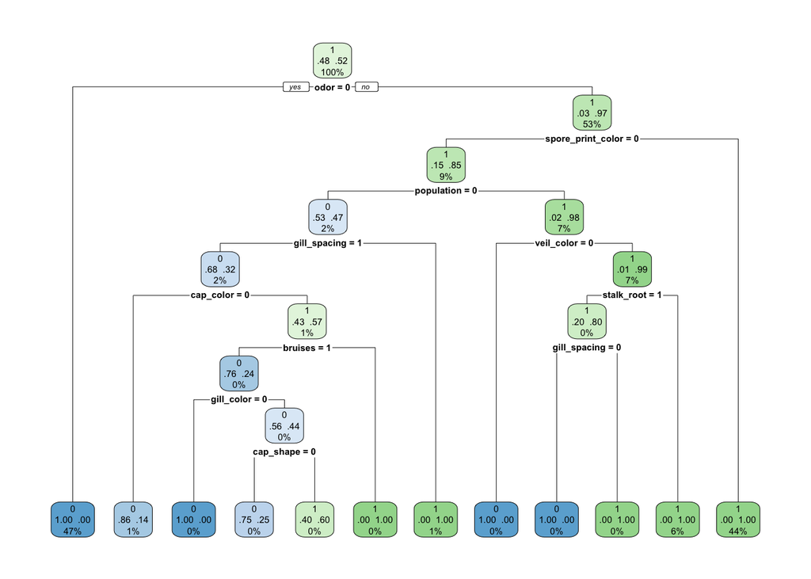

```r
rpart.plot::rpart.plot(
  x = rpart_overfit,
  extra = 104
)
```

```r
prune_overfit <- rpart::prune(
  tree = rpart_overfit,
  cp = 0.004
)
rpart.plot::rpart.rules(
  x = prune_overfit,
  style = "tallw"
)
```

```
## target is 0.00 when
##                odor is 0
##
## target is 0.32 when
##                odor is 1
##                spore_print_color is 0
##                population is 0
##                gill_spacing is 1
##
## target is 0.98 when
##                odor is 1
##                spore_print_color is 0
##                population is 1
##
## target is 1.00 when
##                odor is 1
##                spore_print_color is 0
##                population is 0
##                gill_spacing is 0
##
## target is 1.00 when
##                odor is 1
##                spore_print_color is 1
```

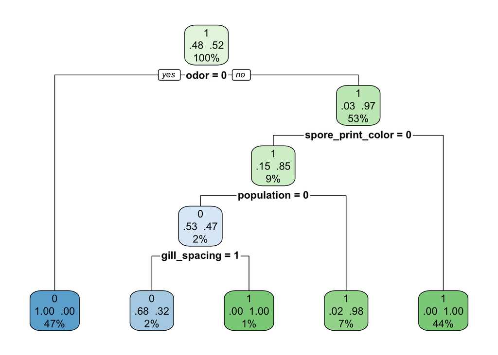

```r
rpart.plot::rpart.plot(
  x = prune_overfit,
  extra = 104
)
```

# Predicting with decision trees

```r
v_rpart <- ls()[grepl(x = ls(),pattern = "^rpart_")]
for(j in v_rpart) M_mushrooms[,j] <- predict(
  object = get(j),
  type = "class",
  newdata = M_mushrooms
)
 M_mushrooms[,c("target","train_test",v_rpart)] %>%
  tidyr::gather(
    key = "model",
    value = "predict",
    -target,-train_test
  ) %>%
  dplyr::mutate(
    target = factor(target),
    predict = factor(predict),
    correct = target == predict
  ) %>%
  dplyr::group_by(model,train_test) %>%
  dplyr::summarise(
    accuracy = mean(correct)
  )
```

```
## # A tibble: 12 × 3
## # Groups:   model [6]
##    model           train_test accuracy
##    <chr>           <chr>         <dbl>
##  1 rpart_1         Test          0.987
##  2 rpart_1         Train         0.987
##  3 rpart_cp        Test          0.996
##  4 rpart_cp        Train         0.996
##  5 rpart_maxdepth  Test          0.996
##  6 rpart_maxdepth  Train         0.996
##  7 rpart_minbucket Test          0.998
##  8 rpart_minbucket Train         0.998
##  9 rpart_minsplit  Test          0.987
## 10 rpart_minsplit  Train         0.987
## 11 rpart_overfit   Test          0.998
## 12 rpart_overfit   Train         0.998
```

We want to focus on the accuracy on the test sets.

## Conclusion

Decision trees are versatile and powerful tools that can be applied to a wide range of tasks from classification to regression. With the capability to intuitively visualize decisions and the flexibility to handle various types of data, they remain a staple in the toolset of many data scientists and researchers. As with any model, care should be taken in tuning and understanding the model to prevent issues like overfitting and to ensure robustness in predictions.

## Homework Problems on Decision Trees Using R

### Problem 1: Basic Decision Tree Construction

**Instructions**:  
1. Select a dataset of your own that contains both categorical and numeric predictor variables along with a target variable (either regression or classification). 2. Using the `rpart` package, build a decision tree model. 3. Visualize the tree using the `plot` and `text` functions.

**Questions**: a. What is the depth of the tree? b. Which variable was used for the first split? c. Describe any two decision paths and their outcomes.

### Problem 2: Evaluating Decision Tree Performance

**Instructions**: 1. Split your dataset into training (70%) and testing (30%) sets. 2. Train a decision tree model on the training set using the `tree` package. 3. Predict the outcomes on the testing set. 4. Evaluate the model’s performance using appropriate metrics (e.g., accuracy, RMSE).

**Questions**: a. Report the performance metric(s) of your model. b. Which predictor variables were most influential in the tree’s decision-making? c. Discuss any potential overfitting or underfitting issues you might observe.

### Problem 3: Tree Pruning

**Instructions**: 1. Using the `rpart` package, construct a decision tree for your dataset. 2. Prune the tree using the `prune` function, experimenting with different complexity parameters. 3. Compare the performance of the pruned tree against the original tree using a validation set or cross-validation.

**Questions**: a. How does the pruned tree’s structure differ from the original? b. What was the optimal complexity parameter for pruning, and why? c. Discuss the performance trade-offs between the pruned and unpruned trees.

### Problem 4: Exploring Interactions with Decision Trees

**Instructions**: 1. Choose a dataset where you suspect interactions between predictor variables. 2. Train a decision tree model using the `party` package (Conditional Inference Trees). 3. Analyze the tree structure to identify any interactions between variables.

**Questions**: a. Describe at least two interactions observed in the tree. b. How do these interactions influence the target variable? c. Discuss the potential real-world implications or interpretations of these interactions.

### Problem 5: Decision Trees with `caret`

**Instructions**: 1. Use the `caret` package to train a decision tree model on your dataset. 2. Utilize `caret`’s tools for data preprocessing (e.g., scaling, encoding) and model tuning (e.g., grid search for optimal parameters). 3. Compare the performance of the `caret`-trained tree with a tree trained using `rpart` without any preprocessing or tuning.

**Questions**: a. What preprocessing steps did `caret` implement on your data? b. What were the optimal parameters determined by `caret` for the decision tree? c. Compare the performance of the two models. Does the additional preprocessing and tuning in `caret` lead to a noticeably better model?